# Lab 3: Plotting Health Data

Brian Teklits, Charles Doremieux, Andrew MacLean, Clint LaBattaglia

9/13/2019

### The Overall Question

**The Question:** How does the amount of weight a person wants to lose relate to their overall current health?

**Why the question is important:** If they are related, it suggests that some respondents are aware their health would improve if they reached their desired weight, but are unable to enact change. These people are interested in making a change, and so policies aimed at helping this group of people should be more effective than those focused on people who are more apathetic to change, or are less in need of larger lifestyle changes.

**Why the answer is relevant:** We can gain insights into how the habits of healthier individuals differ from those in poorer health, and use this to make recommendations on possible change. We can identify age and gender groups that effective policies should target, and factors that make these policies the most effective.

### Team Plot and Conclusions

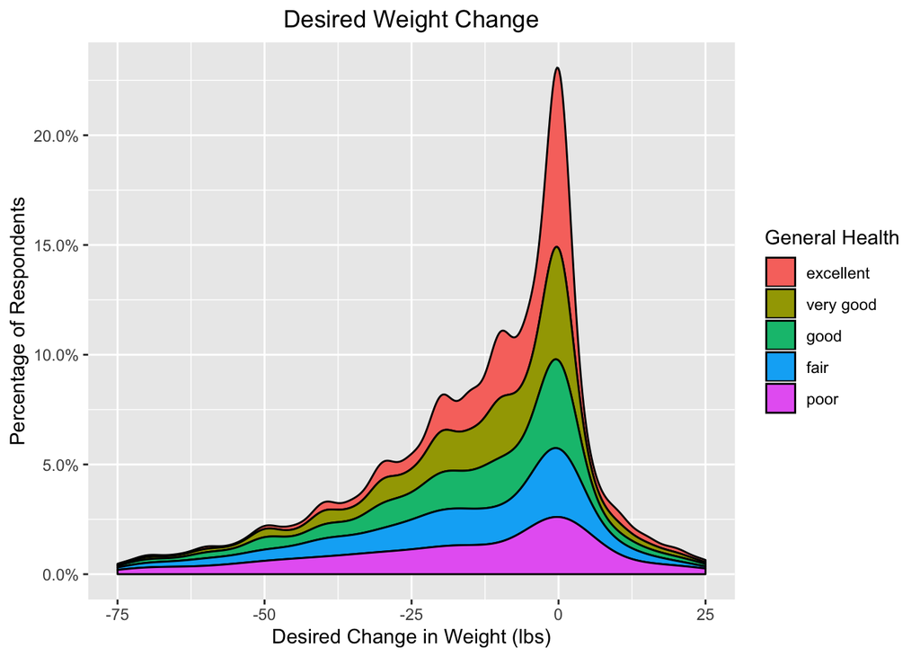

```r
ggplot(cdc)+
  geom_density(aes(x=(wtdesire-weight),y=..density..,fill=genhlth),position="stack")+
  xlim(-75,25)+
  xlab("Desired Change in Weight (lbs)")+
  ylab("Percentage of Respondents")+
  scale_fill_discrete(name="General Health")+
  scale_y_continuous(labels=scales::percent)+
  ggtitle("Desired Weight Change")+
  theme(plot.title = element_text(hjust = 0.5))
```

### Recommendations

People around 45-55 years old are most interested in losing weight, so policy changes should be tailored to this group when possible.

We found that people who are more engaged in improving their health, either through regular exercise or via doctor’s visits, were in general more motivated to make positive lifestyle changes. We recommend both:

- Helping engage people who do not have healthcare with low cost alternatives.
- Encouraging doctors to pursue all available avenues for aiding patients in losing weight.

We noticed a trend in the amount of people who worked out, what generel shape they were in, and the amount of weight they wanted to lose. We found that people who regularly work out only want minimal changes in their weight (<20) instead of large (20>) changes.

We also found that gender has little or no bearing on desired weight/gain or loss. Hence, policies meant to increase and improve health should not be tailored to just men or women. Outreach to both is necessary.

### Individual Findings and Plots

#### Brian’s Plot

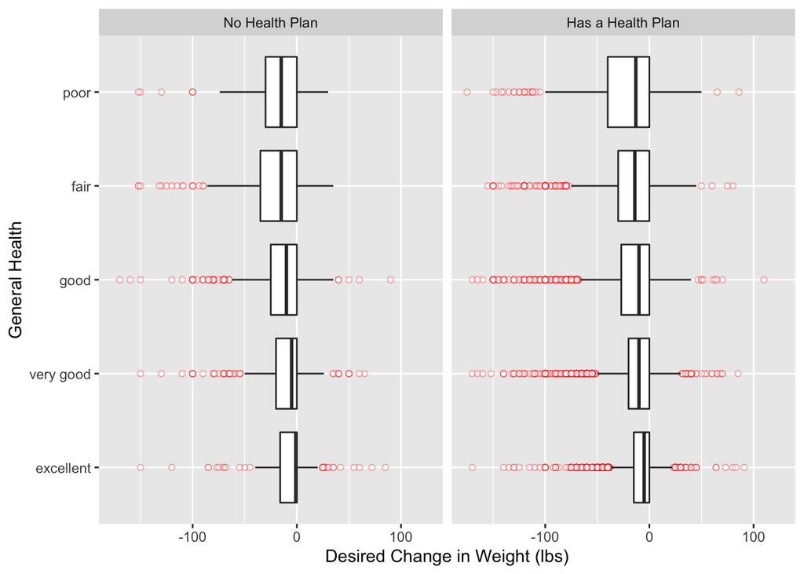

```r
health_plan_label <- as_labeller(c(`0` = "No Health Plan", `1` = "Has a Health Plan"))
ggplot(cdc)+
  geom_boxplot(aes(x=genhlth,y=(wtdesire-weight)),outlier.alpha = .3,outlier.shape = 21,outlier.color = "red")+
  ylim(-175,125)+
  coord_flip()+
  facet_wrap(~hlthplan,labeller = health_plan_label)+
  ylab("Desired Change in Weight (lbs)")+
  xlab("General Health")
```

**Individual Findings:** At all general health levels, we find a larger number of outliers in the health plan group, compared to the no health plan group. Leading us to conclude that people who have a health plan generally want to change their weight more than those who don’t.

This suggests that people who are actively engaged in monitoring their health are better informed on what overall changes they need to make. Engaging the group with no health plan with low cost alternatives, such as health fairs, could help to inform them of what beneficial changes they can make.

Additionally, for those people with healthcare, encouraging doctors to refer patients to dieticians, when health plans allow, could help them to plot a path to their desired weight and health goals.

#### Andrew’s Plot

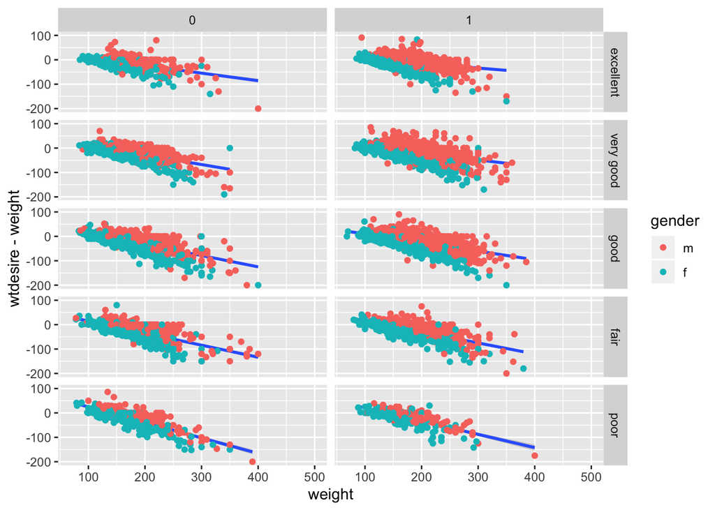

```r
# Andrew's Plot
ggplot(data = cdc, mapping = aes(x = weight, y = wtdesire-weight))+
  geom_smooth(method = 'lm') +
  geom_point(mapping = aes(color = gender))+
  ylim(-200,100)+
  facet_grid(genhlth ~ exerany)
```

#### Clint’s plot

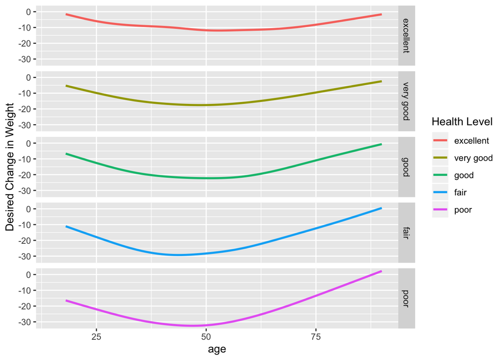

```r
# Clint's Plot
ggplot(data = cdc) + geom_smooth(mapping = aes(x = age, y = (wtdesire-weight), color = genhlth), se = FALSE) + facet_grid(genhlth~.) + xlim(15,90) + ylab("Desired Change in Weight") + scale_color_discrete(name = "Health Level")
```

**Individual Findings:** This graph is useful because it shows how the desired change in weight is greatest at around fifty years old, after which the desired change in weight decreases as individuals age. This graph also demonstrates visually how people who report their health as less than excellent had larger values for desired weight change providing evidence that people who percieve themselves to be in worse shape generally want to change their weight more. I would advise programs that target people in their middle ages (forty-five through fifty-five) for nutrician and weight loss programs to take advantage of the increased desire.

#### Charles’ Plot

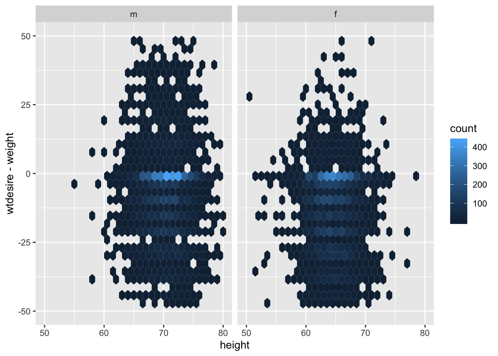

```r
#View(cdc)
# Charles' Plot
#ggplot(data = cdc, mapping = aes(x = genhlth, fill = gender))+
  #geom_bar()+
  #xlim(100,230)+
  #ylim(0,4000)+
  #facet_wrap(~gender)
ggplot(data = cdc, mapping = aes(x = height, y = wtdesire-weight))+
  geom_hex()+
  xlim(50,80)+
  ylim(-50,50)+
  facet_wrap(~gender)
```

### Summary of Individual Contributions

**Brian Teklits:** I helped formulate the overall question, answer, and team plot, as well as figuring out how to label legends, faceted variables, percentage based axes, and titles. I also helped formulate our data based recommendations.

**Andrew:** I created a data plot that represents the amount of weight someone wants to lose vs how much they already weigh and their current health. It allowed us to see the people who workout and are of heavier weight tend to be un happy with their current weight and want to lose more.

**Clint:** I helped formulate the overall question, and created a data plot which revealed the relationship between age and desired weight change which helped formulate our ultimate data based recomendations.

**Charles:** I helped create data plots that represent relationships between gender, height, and desired weight change. I helped formulate the responses to the prompts of the lab. I overlooked the management of document versions and submission timeline. I also helped construct portions of the overall conclusion of our team.